# MiniProject3P2

```python
import numpy as np
from sklearn.manifold import TSNE
import matplotlib.pyplot as plt
from sklearn.cluster import KMeans

# Load the data
data = np.load('pset3-2-if-needed.npz')

# Extract spectra and labels
encoded_spectra = data['encodings']
true_labels = data['labels']
print("Encoded Spectra Shape:", encoded_spectra)
print("Names:", data.files)
```

```
Encoded Spectra Shape: [[ -7.73990645  14.20708052   2.43155901  -4.47838514  -9.8877227 ]
 [-12.49960257   9.83689849  -6.76188366  -5.36037419  -4.44340129]
 [ -5.04818077   8.66011038   3.31588171  -1.40000535  -6.98460052]
 ...
 [ -7.4335317    4.41853153   0.71670563  -3.27610675  -1.42532498]
 [ -6.26572623   4.76730109   3.87804339  -2.43024413  -2.91978998]
 [-11.24851326   6.8915416   -0.81998035  -2.57051746  -4.06928607]]
Names: ['encodings', 'labels']
```

Extracted shapes and labels to check data format

```python
# k-means
kmeans = KMeans(n_clusters=3, random_state=42, n_init="auto").fit(encoded_spectra)
kmeans_labels = kmeans.labels_  # Cluster assignments from k-means
centroids = kmeans.cluster_centers_  # Find Centroids

 # Checking dimensions & labels
print("KMeans Labels Shape:", kmeans_labels.shape)
print("KMeans Labels:", kmeans_labels)
print("Centroids:", centroids)

# Append centroids to the data
combined_data = np.vstack([encoded_spectra, centroids])

# Apply t-SNE to reduce to 2D
tsne = TSNE(n_components=2, random_state=42)
combined_2d = tsne.fit_transform(combined_data)

# Separate coordinates from original data and the centroids
encoded_2d = combined_2d[:-len(centroids)]  # t-SNE coordinates for the original data
centroids_2d = combined_2d[-len(centroids):]  # t-SNE coordinates for the centroids
```

```
KMeans Labels Shape: (787,)
KMeans Labels: [0 0 0 0 0 0 0 0 0 0 0 0 0 0 0 0 0 0 0 0 0 0 0 0 0 0 0 0 0 0 0 0 0 0 0 0 0
 0 0 0 0 0 0 0 0 0 0 0 0 0 0 0 0 0 0 0 0 0 0 0 0 2 0 0 0 0 0 0 0 0 0 0 0 0
 0 0 0 0 0 0 0 0 0 0 0 0 0 0 0 0 0 0 0 0 0 0 0 0 0 0 0 0 0 0 0 0 0 0 0 0 0
 0 0 0 0 0 0 0 0 0 0 0 0 0 0 0 0 0 0 0 0 0 0 0 0 0 0 0 2 0 0 0 0 0 0 2 0 0
 0 0 0 0 0 0 0 0 0 0 0 0 0 0 0 0 0 0 0 0 0 0 0 0 0 0 0 0 0 0 2 0 0 0 0 0 0
 0 0 0 0 0 0 0 0 0 0 0 2 0 0 0 2 0 0 0 0 0 0 0 0 0 0 1 0 0 0 0 0 0 0 0 0 0
 0 0 0 0 0 0 0 0 0 0 0 0 0 0 0 0 0 0 0 0 0 2 0 0 2 0 0 0 0 0 0 0 0 0 0 0 0
 0 0 0 0 0 0 0 0 0 0 0 0 0 0 0 0 0 0 0 0 0 0 2 0 0 0 0 0 0 0 0 0 0 0 0 0 0
 0 0 0 0 0 1 0 0 0 0 2 2 0 0 0 0 0 0 1 0 0 0 0 0 0 0 0 0 1 2 0 0 0 0 0 0 0
 0 2 0 0 0 0 0 0 0 0 0 0 0 0 0 0 0 0 0 0 0 0 0 0 0 0 0 0 0 0 0 0 0 0 0 0 0
 0 0 0 0 0 0 1 0 0 0 0 0 2 0 0 0 0 0 0 0 0 0 0 0 0 0 0 0 0 0 0 0 0 0 0 0 0
 0 0 0 0 0 0 0 0 0 0 0 0 0 0 0 0 0 0 0 0 1 0 0 0 0 1 0 0 0 2 0 0 0 0 0 0 0
 0 0 0 0 0 0 0 2 0 0 0 0 0 0 0 0 0 0 0 0 0 0 0 0 0 0 0 0 0 0 0 0 0 0 0 0 0
 0 0 0 0 0 0 0 0 0 0 0 0 0 0 0 0 2 0 0 0 0 0 0 0 0 0 0 0 0 0 0 2 0 0 0 0 0
 0 0 0 0 0 0 0 0 0 0 0 0 0 0 0 0 0 0 0 0 0 0 0 0 0 0 0 0 0 2 0 0 0 0 0 0 0
 0 0 0 2 0 0 0 0 0 0 0 0 0 0 0 0 0 0 0 0 0 0 0 0 0 0 0 0 0 0 0 0 0 0 0 0 0
 0 0 0 0 0 2 0 0 0 0 0 0 2 0 0 0 0 0 0 0 0 1 0 2 0 0 0 0 0 0 0 0 0 0 0 0 0
 0 0 0 0 0 0 0 0 0 0 0 0 0 0 0 0 0 0 0 0 0 0 0 0 0 0 0 0 0 0 0 0 0 0 0 0 0
 0 0 0 0 0 0 0 0 0 0 0 0 0 0 0 0 0 0 0 0 0 0 0 0 0 0 0 0 0 0 2 0 0 0 0 0 0
 0 0 0 0 0 0 0 0 0 0 0 0 0 0 0 0 0 0 0 0 0 0 0 0 0 0 0 0 0 0 0 0 0 0 0 0 0
 0 0 0 2 0 0 0 0 0 0 0 0 0 0 0 0 0 0 0 0 0 2 0 0 0 0 0 0 0 0 0 0 0 0 0 0 0
 0 0 0 0 0 0 2 0 0 0]
Centroids: [[  -6.82226624    7.6389828    -1.98667832   -4.96514084   -4.12477897]
 [  24.60071218  129.21193765    2.86785992 -140.19613756  -83.79883238]
 [  17.80690005  -30.21823706  -56.44907245  -57.10690841   50.54802494]]
```

Cluster with 3 and find assignments, following sklearn. Checked dimensions to ensure there is no issue later on. Look at centroids to see if they seem reaosnable. Use t_SNE to reduce into 2 dimensions.

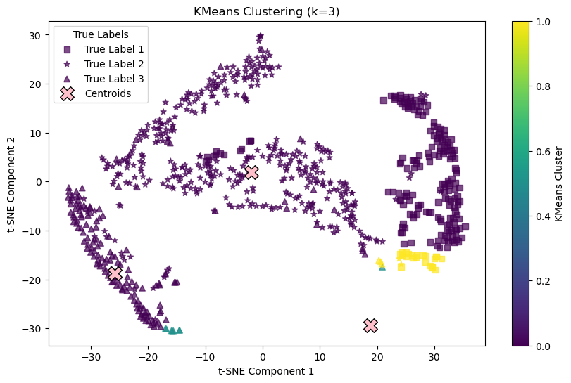

```python
# Set marker shapes
markers = ['o', 's', '*', '^']

# Scatter plot
plt.figure(figsize=(10, 6))

# Plot each true label with a different marker shape
for true_label in np.unique(true_labels):
    # Convert to integer for use as an index (debug)
    true_label_int = int(true_label)

    # Ensure true_label_int is within bounds (debug)
    if true_label_int >= len(markers):
        raise ValueError(f"true_label_int {true_label_int} is out of range for markers list of length {len(markers)}")

    # Filter with current true label:
    mask = (true_labels == true_label)
    plt.scatter(
        encoded_2d[mask, 0],  # First dimension of t-SNE
        encoded_2d[mask, 1],  # Second dimension of t-SNE
        c=kmeans_labels[mask],  # Colour by k-means cluster
        cmap='viridis',
        marker=markers[true_label_int],
        label=f'True Label {true_label_int}',
        alpha=0.7
    )

# Plot the centroids
plt.scatter(
    centroids_2d[:, 0],  # First dimension of t-SNE
    centroids_2d[:, 1],  # Second dimension of t-SNE
    c='pink',
    marker='X',
    s=200,
    label='Centroids',
    edgecolors='black'
)

plt.title('KMeans Clustering (k=3)')
plt.xlabel('t-SNE Component 1')
plt.ylabel('t-SNE Component 2')
plt.legend(title='True Labels')
plt.colorbar(label='KMeans Cluster')
plt.show()
```

Now we will see what happens with k = 4:

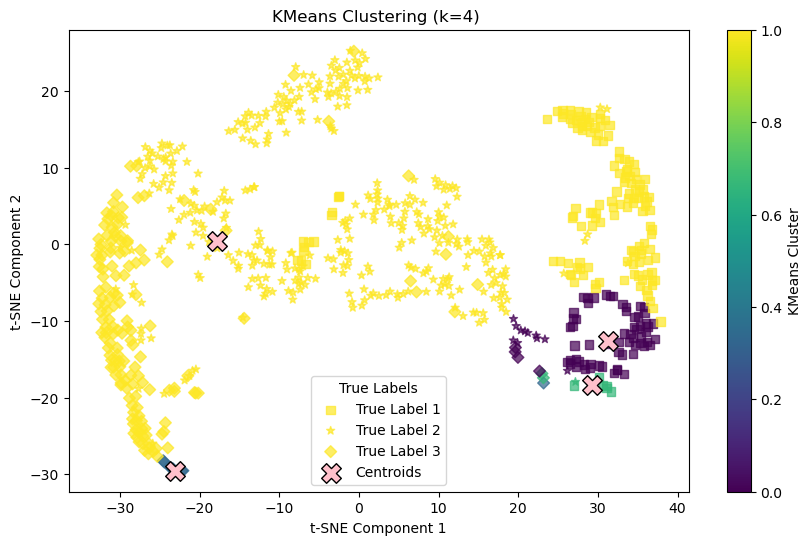

```python
from sklearn.metrics import confusion_matrix, accuracy_score

kmeans = KMeans(n_clusters=4, random_state=42, n_init="auto").fit(encoded_spectra)
kmeans_labels = kmeans.labels_  # Cluster assignments from k-means
centroids = kmeans.cluster_centers_  # Find Centroids

# Append centroids to the data
combined_data = np.vstack([encoded_spectra, centroids])

# Apply t-SNE to reduce to 2D
tsne = TSNE(n_components=2, random_state=42)
combined_2d = tsne.fit_transform(combined_data)

encoded_2d = combined_2d[:-len(centroids)]
centroids_2d = combined_2d[-len(centroids):]


# Define marker shapes for true labels
markers = ['o', 's', '*', 'D']

plt.figure(figsize=(10, 6))

# Plot each true label with a different marker shape
for true_label in np.unique(true_labels):
    true_label_int = int(true_label)

    # Ensure true_label_int is within bounds (debug)
    if true_label_int >= len(markers):
        raise ValueError(f"true_label_int {true_label_int} is out of range for markers list of length {len(markers)}")

    # Filter with current true label:
    mask = (true_labels == true_label)
    plt.scatter(
        encoded_2d[mask, 0],  # First dimension of t-SNE
        encoded_2d[mask, 1],  # Second dimension of t-SNE
        c=kmeans_labels[mask],  # Colour-coded by cluster
        cmap='viridis',
        marker=markers[true_label_int],
        label=f'True Label {true_label_int}',
        alpha=0.7
    )

plt.scatter(
    centroids_2d[:, 0],
    centroids_2d[:, 1],
    c='pink',
    marker='X',
    s=200,
    label='Centroids',
    edgecolors='black'
)

plt.title('KMeans Clustering (k=4) ')
plt.xlabel('t-SNE Component 1')
plt.ylabel('t-SNE Component 2')
plt.legend(title='True Labels')
plt.colorbar(label='KMeans Cluster')
plt.show()
```

Here we see a similar clustering to k = 3. Both are failing to separate shapes into clusters, suggesting k means is not working well at all.The purple cluster may be more accurate as it contains a lot fo square labels.

```python
# Look at true labels
# Create a confusion matrix (researched this)
conf_matrix = confusion_matrix(true_labels, kmeans_labels)
print("Confusion Matrix:")
print(conf_matrix)

# Calculate accuracy (if true labels are known)
accuracy = accuracy_score(true_labels, kmeans_labels)
print(f"Accuracy: {accuracy:.2f}")
```

```
Confusion Matrix:
[[  0   0   0   0]
 [ 61   0   6 138]
 [ 11   0   1 405]
 [  4   8   2 151]]
Accuracy: 0.19
```

Here we see that this has a low accuracy. Some clusters dominate, while others are underpopulated. The accuracy of 0.19 (19%) indicates that only 19% of the data points are correctly assigned.

b)

Steps:  
Gaussian Mixture Model to the data  
Extract the cluster assignments and the Gaussian distributions (means and covariances)  
Use t-SNE to reduce the data to 2D for visualisation  
Plot the data points, colour coding by GMM cluster assignments; marker shapes to represent their true labels  
Repeat for k=4

```python
# Reimporting to allow for debuging later on (having lots of issues with restarting kernel and losing variables)
import numpy as np
from sklearn.mixture import GaussianMixture
from sklearn.manifold import TSNE
import matplotlib.pyplot as plt
import matplotlib as mlp
from scipy.stats import multivariate_normal
```

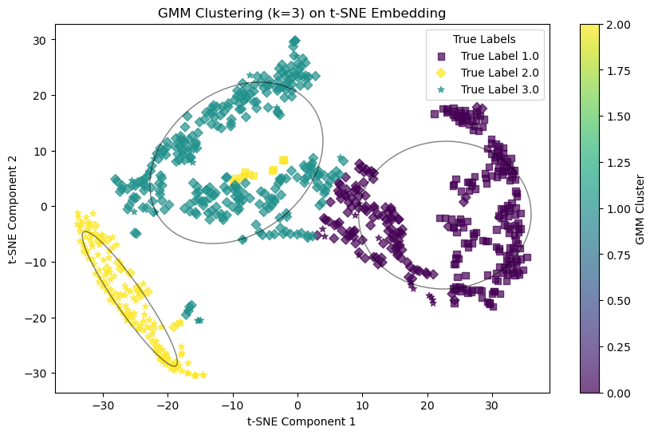

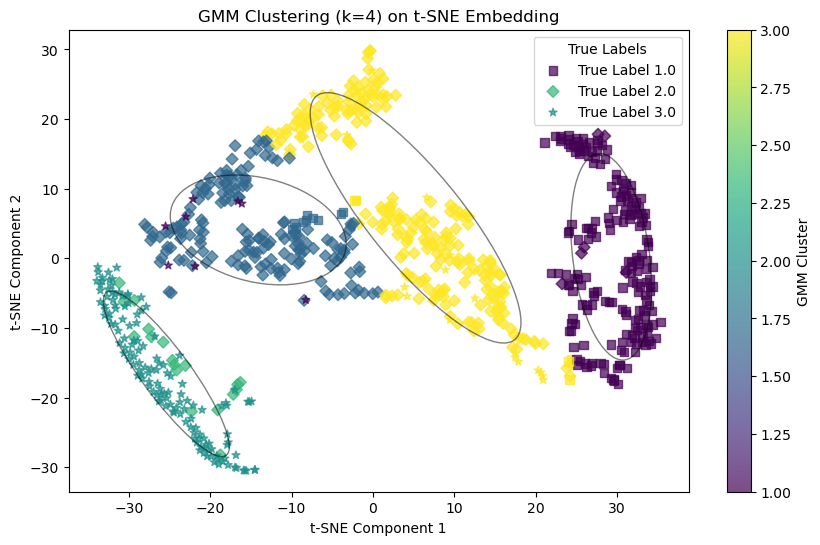

```python
# Load the data
data = np.load('pset3-2-if-needed.npz')
encoded_spectra = data['encodings']
true_labels = data['labels']

# Helper function to draw ellipsoidal contours
def make_ellipses(gmm, ax, my_var1=0, my_var2=1):
    """
    Primarily stolen from: https://scikit-learn.org/stable/auto_examples/mixture/plot_gmm_covariances.html
    gmm: GaussianMixture object from sklearn
    ax: Matplotlib axis, indication of where to plot the contour
    my_var1: int, x-axis in the latent space where you are plotting
    my_var2: int, y-axis in the latent space where you are plotting
    """
    for n in np.arange(len(gmm.covariances_)):
        covariances = gmm.covariances_[n][[[my_var1, my_var1], [my_var1, my_var2]], [[my_var1, my_var2], [my_var2, my_var2]]]
        v, w = np.linalg.eigh(covariances)  # Returns the eigenvalues / vectors of our covariance matrix
        u = w[0] / np.linalg.norm(w[0])
        angle = np.arctan2(u[1], u[0])
        angle = 180 * angle / np.pi  # Convert to degrees
        v = 2.0 * np.sqrt(2.0) * np.sqrt(v)
        ell = mlp.patches.Ellipse(
            gmm.means_[n, [my_var1, my_var2]], v[0], v[1], angle=180 + angle, edgecolor='k', lw=1, facecolor='none'
        )
        ell.set_clip_box(ax.bbox)
        ell.set_alpha(0.5)
        ax.add_artist(ell)

# Latent space reduced to 2D
tsne = TSNE(n_components=2, random_state=42)
encoded_2d = tsne.fit_transform(encoded_spectra)

# GMM and plot results:
def fit_and_plot_gmm(k, encoded_2d, true_labels):
    # Fit Gaussian Mixture Model
    gmm = GaussianMixture(n_components=k, random_state=42)
    gmm_labels = gmm.fit_predict(encoded_2d)

    # Plot
    plt.figure(figsize=(10, 6))
    markers = ['o', 's', 'D', '*']
    colours = plt.cm.viridis(np.linspace(0, 1, k))

    # Plot each point
    for true_label in np.unique(true_labels):
        mask = (true_labels == true_label)
        plt.scatter(
            encoded_2d[mask, 0],
            encoded_2d[mask, 1],
            c=gmm_labels[mask],  # Colour by cluster
            cmap='viridis',  # Colourmap
            marker=markers[int(true_label)],  # Marker shape = label
            label=f'True Label {true_label}',
            alpha=0.7
        )

    # Draw ellipsoidal contours for each cluster
    make_ellipses(gmm, plt.gca())

    # Add labels and legend
    plt.title(f'GMM Clustering (k={k}) on t-SNE Embedding')
    plt.xlabel('t-SNE Component 1')
    plt.ylabel('t-SNE Component 2')
    plt.legend(title='True Labels')
    plt.colorbar(label='GMM Cluster')
    plt.show()

# Fit and plot for k=3
fit_and_plot_gmm(k=3, encoded_2d=encoded_2d, true_labels=true_labels)

# Fit and plot for k=4
fit_and_plot_gmm(k=4, encoded_2d=encoded_2d, true_labels=true_labels)
```

By increase k from 3 to 4, the green/blue and purple cluster in k =3 breaks down to three clusters. The ellipses are almost overlapping.

c)